# Quarto example - Verena

Some text, plots and tables from a NBIS user-fee project

Author

Verena Kutschera

Published

May 14, 2024

## Data

### Library construction and sequencing (from NGI report)

Libraries were construction using the Illumina TruSeq PCR-free library prep kit. Samples were sequenced on NovaSeq6000 in a ‘S4’ mode flowcell. Bcl to FastQ conversion was performed using bcl2fastq_v2.20.0.422 from the CASAVA software suite.

- Raw data location on Rackham: `/proj/snic2020-X-XXX/private/DataDelivery_2023-XX-XX_XX-XX-XX_ngisthlm00XXX/files/PXXXXX`
  - Please note that NBIS recommends to submit raw data to ENA as soon as possible

Table 1: Sample metadata

| Sample_ID | NGI_ID | Mreads | >=Q30 | Date | Sex |
| --- | --- | --- | --- | --- | --- |
| F34 | PXXXXX_113 | 109.65 | 90.04 | 2022 | F |
| F41 | PXXXXX_114 | 119.48 | 89.87 | 2022 | M |
| F42 | PXXXXX_115 | 91.88 | 89.91 | 2022 | F |
| F43 | PXXXXX_116 | 106.51 | 89.93 | 2022 | F |
| F44 | PXXXXX_117 | 112.15 | 89.75 | 2022 | M |
| O1 | PXXXXX_101 | 110.42 | 89.80 | 2022 | M |
| O11 | PXXXXX_203 | 136.61 | 90.22 | 2022 | M |
| O15 | PXXXXX_107 | 110.25 | 89.98 | 2022 | M |
| O16 | PXXXXX_108 | 102.67 | 89.62 | 2022 | F |

*Sample_ID: sample identifier used for sampling and laboratory* *work. NGI_ID: NGI sample identifier, Mreads:total million* *read pairs for a sample,>=Q30: aggregated percentage of bases* *that have a quality score >= Q30, Longitude / Latitude:* *geographic sampling location, Date: sampling year,* *Sex: M=male, F=female*

## Some methods

### Whole-genome sequencing data processing

Whole-genome sequencing data from nine individuals (Table 1) were processed and analysed using GenErode v0.6.0 (Kutschera et al. 2022) with default settings if not otherwise described.

## Some results

### Population structure

F<sub>ST</sub> was calculated in 50 kb windows between island and mainland samples. The mean F<sub>ST</sub> across all 50 kb windows (with zero missing data allowed) was 0.036.

```python
import os
import pandas as pd
import numpy as np

def mean_fst(fst_file):
    fst_df = pd.read_table(fst_file, delim_whitespace=True, header=0)
    mean_fst = fst_df['MEAN_FST'].mean()
    print(mean_fst)

fst = "windowed.weir.fst"

mean_fst(fst)
```

```
0.03610024109357622
```

### Genome-wide heterozygosity

We estimated individual heterozygosity calculated as the number of heterozygote sites (i.e., SNPs) per site (theta = *4Neμ*) using mlRho.

```python
import pandas as pd
import scipy.stats as stats

def mlRho_dataframe(inputfiles):
    # define a function to get the input data
    dataframes = []
    for infile in inputfiles:
        dataset = str(infile).split(".")[0]
        with open(infile) as f:
            for i in f: # create one dataframe per input file
                path_list = i.split("/")
                sample = path_list[-1].split(".")[0]
                genomeregion = path_list[-1].split(".")[-3]
                if genomeregion == "genome":
                    genomeregion = "genomewide"
                elif genomeregion == "autos":
                    genomeregion = "autosomes"
                elif genomeregion == "sexchr":
                    genomeregion = "sexchromosomes"
                sample_df=pd.read_table(i.strip(), delim_whitespace=True, comment='#')
                sample_df.insert(0, 'dataset', [dataset])
                sample_df.insert(1, 'sample', [sample])
                sample_df.insert(2, 'genomeregion', [genomeregion])
                dataframes.append(sample_df)
    conc_df = pd.concat(dataframes) # concatenate all dataframes
    conc_df.reset_index(drop=True, inplace=True)
    conc_df = conc_df.sort_values(by = ['dataset', 'sample'], ascending = [True, True])
    return conc_df

def process_mlrho_dataframe(mlrho_df):
    # function to read in and process the data
    mlrho_df['lower_theta'] = mlrho_df['theta'].str.split('<').str[0].astype(float)
    mlrho_df['theta_est'] = mlrho_df['theta'].str.split('<').str[1].astype(float)
    mlrho_df['upper_theta'] = mlrho_df['theta'].str.split('<').str[2].astype(float)
    grouped_df = mlrho_df.groupby('dataset')
    return mlrho_df, grouped_df

def mann_whitney_u(statistic, dataset1, list1, dataset2, list2):
    # perform Wilcoxon rank-sum test (equivalent to Mann-Whitney U test)
    print('**** Mann-Whitney U test of',statistic,'****\n')
    stat, p_value = stats.mannwhitneyu(list1, list2)
    print('\tU=%.2f, p=%.2f' % (stat, p_value))

    # Level of significance
    alpha = 0.05
    # conclusion
    if p_value < alpha:
        print('\tRejecting Null Hypothesis (Significant difference between the two samples)')
    else:
        print('\tCannot Reject Null Hypothesis (No significant difference between the two samples)')

    print('\n\tSamples and sample sizes:\n\t', dataset1,'n =',len(list1), '\n\t', dataset2, 'n =', len(list2))

# read in the data
infiles = ['mainland.txt', 'island.txt']

# apply the functions
mlRho_df = mlRho_dataframe(infiles)
tabledf, groupeddf = process_mlrho_dataframe(mlRho_df)

listdf = tabledf.groupby('dataset')['theta_est'].apply(list)

print('Mainland:')
print('\tMedian heterozygosity %.6f' % (pd.Series(listdf['mainland']).median()))
print('\tMinimum heterozygosity %.6f' % (pd.Series(listdf['mainland']).min()))
print('\tMaximum heterozygosity %.6f' % (pd.Series(listdf['mainland']).max()), '\n')

print('Island:')
print('\tMedian heterozygosity %.6f' % (pd.Series(listdf['island']).median()))
print('\tMinimum heterozygosity %.6f' % (pd.Series(listdf['island']).min()))
print('\tMaximum heterozygosity %.6f' % (pd.Series(listdf['island']).max()), '\n')

mann_whitney_u('Heterozygosity', 'Mainland', listdf['mainland'], 'Island', listdf['island'])
```

```
Mainland:
    Median heterozygosity 0.000731
    Minimum heterozygosity 0.000709
    Maximum heterozygosity 0.000739

Island:
    Median heterozygosity 0.000695
    Minimum heterozygosity 0.000594
    Maximum heterozygosity 0.000737

**** Mann-Whitney U test of Heterozygosity ****

    U=16.50, p=0.14
    Cannot Reject Null Hypothesis (No significant difference between the two samples)

    Samples and sample sizes:
     Mainland n = 5
     Island n = 4
```

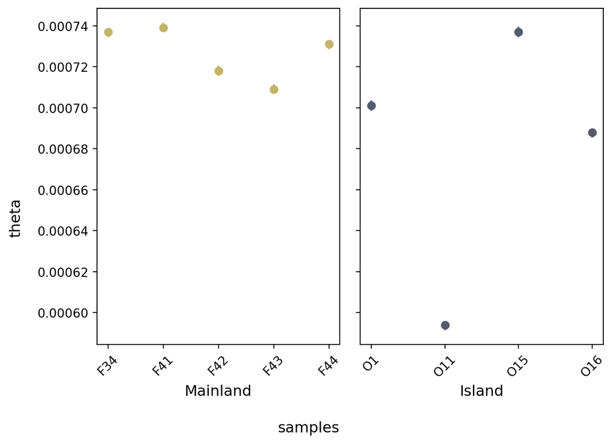

Figure 1: Genome-wide autosomal individual heterozygosity of nine individuals. Theta = *4Neμ* = number of heterozygous sites per site. Error bars represent 95% confidence intervals.

```python
import matplotlib.pyplot as plt
import pandas as pd
from matplotlib import cm
from matplotlib.colors import ListedColormap, LinearSegmentedColormap

def theta_plot(dataframe, grouped, dataset, ax, color):
    # function for the subplots
    data_df = grouped.get_group(dataset)
    for lower,theta,upper,x in zip(data_df['lower_theta'],data_df['theta_est'],data_df['upper_theta'],range(len(data_df))):
        ax.plot((x,x),(lower,upper),'-',color=color)
        ax.plot((x),(theta),'o',color=color)
    ax.set_xticks(range(len(data_df)))
    ax.set_xticklabels(list(data_df['sample']), rotation = 45)

def combine_theta_plots(dataframe, grouped):
    # function to create the combined plot
    cividis = cm.get_cmap('cividis', 256) # create the cividis colormap
    fig, (ax1, ax2) = plt.subplots(ncols=2, sharey=True)
    ax1.set_xlabel("Mainland", fontsize=12)
    ax2.set_xlabel("Island", fontsize=12)
    theta_plot(dataframe, grouped, "mainland", ax1, cividis.colors[200])
    theta_plot(dataframe, grouped, "island", ax2, cividis.colors[80])
    fig.supxlabel('samples') # x axis label

    fig.supylabel('theta', fontsize=12) # common y axis label
    fig.align_labels() # align axis labels

    plt.tight_layout()
    plt.show()

combine_theta_plots(tabledf, groupeddf)
```

## References

Kutschera, Verena E., Marcin Kierczak, Tom van der Valk, Johanna von Seth, Nicolas Dussex, Edana Lord, Marianne Dehasque, et al. 2022. “GenErode: A Bioinformatics Pipeline to Investigate Genome Erosion in Endangered and Extinct Species.” *BMC Bioinformatics* 23: 1–17. https://doi.org/10.1186/S12859-022-04757-0.